# Litter Reduction Act 2015

Policy Administrators

22 November 2015

# 1 Policy Statement

**Reduce street litter by 75%.**

The policy applies the administrative area of North Lanarkshire:

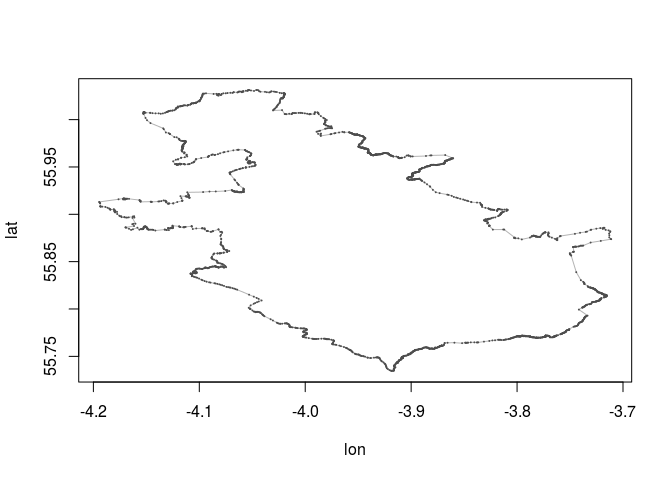

# 2 Litter

| category | name | description | reduction_target |
| --- | --- | --- | --- |
| 1 | Dangerous | Harmful litter which threatens human life | 75 |
| 2 | Harmful | Harmful litter which could severely injury human health | 75 |
| 3 | Severe | Litter posing moderate risk to human health | 75 |
| 4 | Nuisance | Litter posing minor risk to human health | 75 |
| 5 | Minor | Litter posing minimal or no risk to human health | 75 |

# 3 Public highways

Publicly accessible streets excluding gated or no access highways. The street area covers the entire width of the thorough fare up until meeting with private or fenced property. Including the road verge or sidewalk.

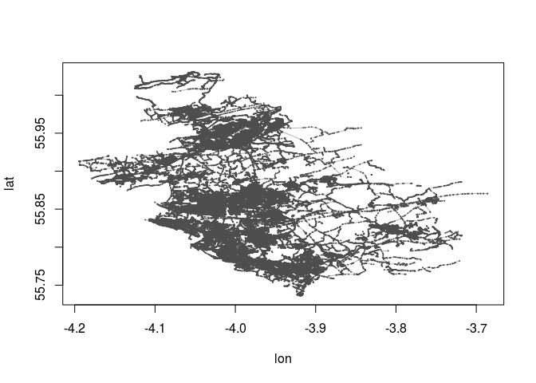

Map of streets

# 4 Reduction

The reduction target of 75% is based on a snapshot of highways within the admin area of North Lanarkshire  
taken at the start of a four year programme. The snapshot survey will be recorded again each year at approximately the same time of year.

# 5 Snapshot survey

The snapshot will select 5% of the highway network as defined in OpenStreetMap as highway in (‘primary’,‘secondary’,‘tertiary’,‘residential’,‘unclassified’) and access not = ‘no’

Each 2km section of randomly selected highway will be selected. Each section split into 100m sub-sections. The survey will assess each 100m section, taking photos and identifying the amount of each category of litter found.

[output not shown]

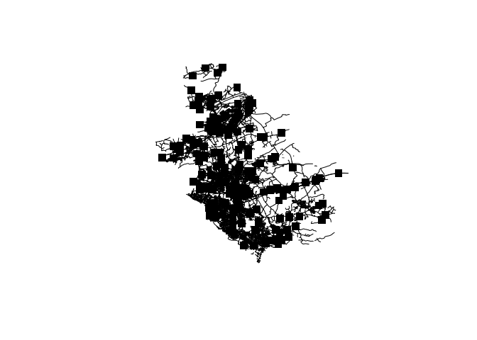

Litter Survey Points

# 6 Social survey

The a survey of 500 people will record social attitudes to litter via webiste questionaire

The questions will be:

Social attitude questionaire

| question | answers |
| --- | --- |
| How old are you? | < 16,16-20,20-30,30-45,45-65,>65 |
| Which postal area to you live in? | text |
| Do you drop litter? | yes,no |
| In the last week have you dropped litter? | yes,no |
| Does litter concern you? | very high concern,high concern,moderate concern,low concern,not concerned |
| How much litter have you seen in the last week? | huge amount of litter,large amount of litter,moderate amount of litter,minor amount of litter,no litter |
| Would you be interested to participant in litter picking? | yes,no |
| How many times per year who you participant? | numeric |

# 7 Policy tools

## 7.1 Fines

Increased Litter Fine Categories (continued below)

| category | name | description | reduction_target |
| --- | --- | --- | --- |
| 1 | Dangerous | Harmful litter which threatens human life | 75 |
| 2 | Harmful | Harmful litter which could severely injury human health | 75 |
| 3 | Severe | Litter posing moderate risk to human health | 75 |
| 4 | Nuisance | Litter posing minor risk to human health | 75 |
| 5 | Minor | Litter posing minimal or no risk to human health | 75 |

| fine_categories |
| --- |
| 100 |
| 200 |
| 400 |
| 800 |
| 1600 |

## 7.2 Street cleaning budget

## 7.3 Number of public rubbish bins

## 7.4 Budget for education

## 7.5 Buget for re-education

## 7.6 Community litter action

## 7.7 Private sector action

Example data:

| year | percentage_drop |
| --- | --- |
| 2015 | 0 |
| 2016 | 10 |
| 2017 | 20 |
| 2018 | 30 |
| 2019 | 75 |